# scratchwork

Esa

# Setup

```r
#This is from the main .Rmd file and is Alice's code

library(tidyverse)
```

```r
library(ggplot2)
#library(rcompanion)
#library(rstatix)
library(BayesFactor)
library(freqtables)

cleanedData_cvd4 <- read_csv("cleanedData_cvd4.csv")
dfCvd4Data <- data.frame(cleanedData_cvd4[,1])
for (column in c(2:ncol(cleanedData_cvd4))){
  dfCvd4Data <- cbind(dfCvd4Data, cleanedData_cvd4[,column])
}
# drop people who skipped whole sections
dfCvd4Data <- subset(dfCvd4Data, dfCvd4Data$drop == 0)

# drop people who are colorblind or skipped that q
dfCvd4Data <- subset(dfCvd4Data, dfCvd4Data$cb == 'not_colorblind')

# drop people who put in answers less than 1 or greater than 100, or NAN
dfCvd4Data <- subset(dfCvd4Data, (dfCvd4Data$ans1 > 0 & dfCvd4Data$ans1 <= 100))
dfCvd4Data <- subset(dfCvd4Data, !is.na(dfCvd4Data$ans1))
dfCvd4Data <- subset(dfCvd4Data, (dfCvd4Data$ans2 >= 0 & dfCvd4Data$ans2 <= 100))
dfCvd4Data <- subset(dfCvd4Data, !is.na(dfCvd4Data$ans2))

currCvd4Data <- data.frame("ID" = dfCvd4Data[,2], "stim" = dfCvd4Data[,4], "corr" = dfCvd4Data[,61], "spatial" = dfCvd4Data[,62])


# How many people does that leave as participants?
nrow(dfCvd4Data)
```

```
## [1] 76
```

There are 76 participants left.

# Ego centric screening questions

I was confused by the ans01 and ans02 screening questions, and realized that they both record the complete answer to both ego questions, at the times before (ans01) and after (ans02) the participant sees the bayes reasoning questions.

## Alice’s work

```r
egoRightWrong <- data.frame(Study=character(), corr=integer())

#filtering data to keep those who got the screening questions correct the first time (before cvd questions)
cvd4ego <- subset(dfCvd4Data, dfCvd4Data$ans01 == 'true positive')

egoRight <- data.frame("ID" = cvd4ego[,2], "stim" = cvd4ego[,4], "corr" = cvd4ego[,61], "spatial" = cvd4ego[,62])

print(nrow(egoRight))
```

```
## [1] 51
```

```r
#filtering data to keep those who got screening questions correct the second time (after seeing the cvd questions)
cvd4ego2 <- subset(dfCvd4Data, dfCvd4Data$ans02 == 'true positive')

egoRight2 <- data.frame("ID" = cvd4ego2[,2], "stim" = cvd4ego2[,4], "corr" = cvd4ego2[,61], "spatial" = cvd4ego2[,62])

print(nrow(egoRight2))
```

```
## [1] 55
```

```r
for(row in 1:nrow(egoRight)){
  temp <- data.frame("egoRight", egoRight[row, 3])
  names(temp) <- c("Study", "corr")
  egoRightWrong <- rbind(egoRightWrong, temp)
}

for(row in 1:nrow(egoRight2)){
  temp <- data.frame("egoRight2", egoRight2[row, 3])
  names(temp) <- c("Study", "corr")
  egoRightWrong <- rbind(egoRightWrong, temp)
}

for(row in 1:nrow(currCvd4Data)){
   temp <- data.frame("cvd4", currCvd4Data[row, 3])
  names(temp) <- c("Study", "corr")
  egoRightWrong <- rbind(egoRightWrong, temp)
}

#str(egoRightWrong)

egoRightWrongProp <- prop.test(x = c(sum(egoRight$corr), sum(currCvd4Data$corr)), n = c(nrow(egoRight), nrow(currCvd4Data)))
egoRightWrongProp
```

[output not shown]

[figure not shown]

```r
#plot -- frequency table
plt <- egoRightWrong %>%
  freq_table(Study, corr)

plt <- as.data.frame(plt)
plt <- subset(plt, plt$col_cat == 1)
plt$row_cat <- as.factor(plt$row_cat)
plt$sa <- "egoRightWrong Data"

#graph
g <- ggplot(plt,aes(x = row_cat, y = percent_row,
               group = row_cat, color = row_cat)) +
  ylim(0, 100) +
  geom_pointrange(aes(ymin = lcl_row, ymax = ucl_row), size = 1) +
  geom_text(aes(label=sprintf("%0.2f", round(percent_row, digits = 2))),
            color = "black", vjust=-1, size = 4) +
  labs(x = "Question", y = 'Proportion of Correct Answers') +
 # scale_x_discrete(labels = c("ego (2nd)", "ego (1st)", "cvd-Bayes")) +
  theme_classic() +
  theme(legend.position = "none", text = element_text(size=15),
        aspect.ratio=1/3) +
  coord_flip() +
  scale_color_brewer(palette="Dark2")
g
```

## How many people got each individual screening question correct?

Out of personal curiosity more than anything – the analysis isn’t looking at the questions individually, but as a unit

```r
#filtering data to keep those who got screening question 1 correct ...
#...the first time
print("Got the first question correct the first time")
```

```
## [1] "Got the first question correct the first time"
```

```r
print(nrow(dfCvd4Data %>% filter(ans01 == 'true positive' | ans01 == 'false positive')))
```

```
## [1] 61
```

```r
#...the second time
print("Got the first question correct the second time")
```

```
## [1] "Got the first question correct the second time"
```

```r
print(nrow(dfCvd4Data %>% filter(ans02 == 'true positive' | ans02 == 'false positive')))
```

```
## [1] 64
```

```r
#filtering data to keep those who got screening question 2 correct...
#...the first time
print("Got the second question correct the first time")
```

```
## [1] "Got the second question correct the first time"
```

```r
print(nrow(dfCvd4Data %>% filter(ans01 == 'true positive' | ans02 == 'false negative')))
```

```
## [1] 53
```

```r
#...the second time
print("Got the second question correct the second time")
```

```
## [1] "Got the second question correct the second time"
```

```r
print(nrow(dfCvd4Data %>% filter(ans02 == 'true positive' | ans02 == 'false negative')))
```

```
## [1] 57
```

```r
#people who got both correct...
#...the first time
print("Got both questions correct the first time")
```

```
## [1] "Got both questions correct the first time"
```

```r
print(nrow(dfCvd4Data %>% filter(ans01 == 'true positive')))
```

```
## [1] 51
```

```r
#...the second time
print("Got both questions correct the second time")
```

```
## [1] "Got both questions correct the second time"
```

```r
print(nrow(dfCvd4Data %>% filter(ans02 == 'true positive')))
```

```
## [1] 55
```

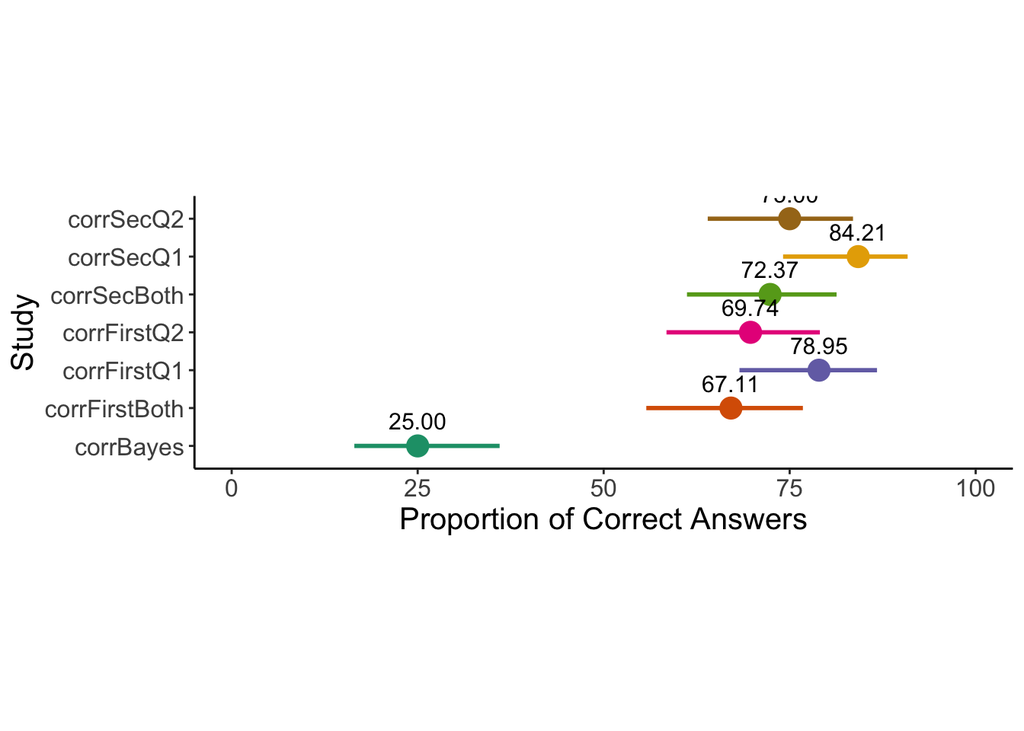

```r
allQsData <- dfCvd4Data %>%
  select(postId, stim, ans01, ans02, ans1, ans2) %>%
  mutate(corrFirstQ1 = ifelse(ans01 == 'true positive' | ans02 == 'false positive', 1, 0),
         corrFirstQ2 = ifelse(ans01 == 'true positive' | ans02 == 'false negative', 1, 0),
         corrSecQ1 = ifelse(ans02 == 'true positive' | ans02 == 'false positive', 1, 0),
         corrSecQ2 = ifelse(ans02 == 'true positive' | ans02 == 'false negative', 1, 0),
         corrFirstBoth = ifelse(ans01 == 'true positive', 1, 0),
         corrSecBoth = ifelse(ans02 == 'true positive', 1, 0),
         corrBayes = ifelse(ans1 == 57 & ans2 == 56, 1, 0)) %>%
  select(corrFirstQ1, corrFirstQ2, corrSecQ1, corrSecQ2, corrFirstBoth, corrSecBoth, corrBayes) %>%
  pivot_longer(c(corrFirstQ1, corrFirstQ2, corrSecQ1, corrSecQ2, corrFirstBoth, corrSecBoth, corrBayes), names_to = "question", values_to = "correct") %>%
  freq_table(question, correct) %>%
  filter(col_cat == 1)

  #taken from alice's graph code
ggplot(allQsData, aes(x = row_cat, y = percent_row,
               group = row_cat, color = row_cat)) +
  ylim(0, 100) +
  geom_pointrange(aes(ymin = lcl_row, ymax = ucl_row), size = 1) +
  geom_text(aes(label=sprintf("%0.2f", round(percent_row, digits = 2))),
            color = "black", vjust=-1, size = 4) +
  labs(x = "Study", y = 'Proportion of Correct Answers') +
  theme_classic() +
  theme(legend.position = "none", text = element_text(size=15),
        aspect.ratio=1/3) +
  coord_flip() +
  scale_color_brewer(palette="Dark2")
```

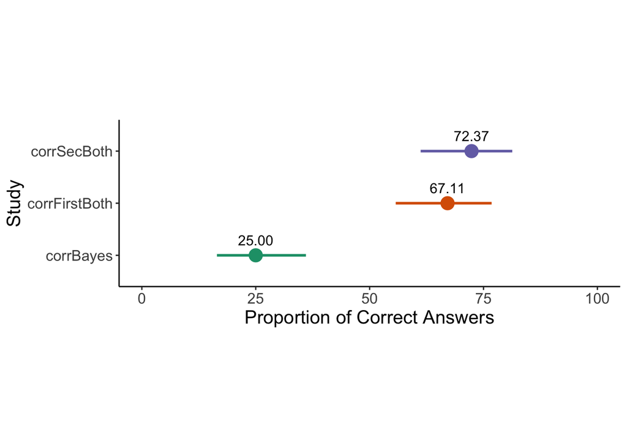

```r
allQsData %>%
  filter(row_cat == "corrFirstBoth" | row_cat == "corrSecBoth" | row_cat == "corrBayes") %>%
  ggplot(aes(x = row_cat, y = percent_row, group = row_cat, color = row_cat)) +
  ylim(0, 100) +
  geom_pointrange(aes(ymin = lcl_row, ymax = ucl_row), size = 1) +
  geom_text(aes(label=sprintf("%0.2f", round(percent_row, digits = 2))),
            color = "black", vjust=-1, size = 4) +
  labs(x = "Study", y = 'Proportion of Correct Answers') +
  theme_classic() +
  theme(legend.position = "none", text = element_text(size=15),
        aspect.ratio=1/3) +
  coord_flip() +
  scale_color_brewer(palette="Dark2")
```

```r
dfCvd4Data %>% summarize(sum(corr)/n())
```

```
##   sum(corr)/n()
## 1          0.25
```

```r
dfCvd4Data %>% group_by(ans01, ans02) %>%
  filter(ans01 != ans02) %>%
  select(ans1, ans2, ans01, ans02) %>%
  mutate(n =n()) %>%
  distinct()
```

```
## # A tibble: 4 x 5
## # Groups:   ans01, ans02 [2]
##    ans1  ans2 ans01          ans02             n
##   <dbl> <dbl> <chr>          <chr>         <int>
## 1    56    32 true negative  true positive     3
## 2    56    80 true negative  true positive     3
## 3    56    80 false positive true positive     1
## 4    56    57 true negative  true positive     3
```

```r
dfCvd4Data %>%
  select(postId, stim, ans01, ans02, ans1, ans2) %>%
  mutate(corrFirstQ1 = ifelse(ans01 == 'true positive' | ans02 == 'false positive', 1, 0),
         corrFirstQ2 = ifelse(ans01 == 'true positive' | ans02 == 'false negative', 1, 0),
         corrSecQ1 = ifelse(ans02 == 'true positive' | ans02 == 'false positive', 1, 0),
         corrSecQ2 = ifelse(ans02 == 'true positive' | ans02 == 'false negative', 1, 0),
         corrFirstBoth = ifelse(ans01 == 'true positive', 1, 0),
         corrSecBoth = ifelse(ans02 == 'true positive', 1, 0),
         corrBayes = ifelse(ans1 == 57 & ans2 == 56, 1, 0)) %>%
  select(corrFirstBoth, corrSecBoth, corrBayes) %>%
  summarize(total = n(),
            tot_first = sum(corrFirstBoth),
            tot_sec = sum(corrSecBoth),
            tot_bayes = sum(corrBayes))
```

```
##   total tot_first tot_sec tot_bayes
## 1    76        51      55        19
```

# Question 4

Compare proportions of correct answers on the reasoning questions between participants who did get the attention check questions correct and participants who did not get the attention check questions correct.

In order to do this, I need to divide participants into those who got the attention check questions correct and those who did not, and then see how each of those two groups did on the reasoning questions.

First, how many people in got the attention check questions correct and the reasoning questions correct?

```r
dfCvd4Data %>%
  select(postId, stim, ans01, ans02, ans1, ans2) %>%
  mutate(corrFirstEgo = ifelse(ans01 == 'true positive', 1, 0),
         corrSecEgo = ifelse(ans02 == 'true positive', 1, 0),
         corrBayes = ifelse(ans1 == 57 & ans2 == 56, 1, 0)) %>%
  select(postId, stim, corrFirstEgo, corrSecEgo, corrBayes) %>%
  group_by(corrFirstEgo, corrBayes) %>%
  summarize(n())
```

```
## # A tibble: 4 x 3
## # Groups:   corrFirstEgo [2]
##   corrFirstEgo corrBayes `n()`
##          <dbl>     <dbl> <int>
## 1            0         0    22
## 2            0         1     3
## 3            1         0    35
## 4            1         1    16
```

Of the people 21 participants who got the attention check questions wrong (the second time), 18 of them got the reasoning questions wrong and 3 of them got the reasoning questions correct. Of the 55 participants who got the attention check questions correct (the second time), 39 of them got the reasoning questions wrong and 16 of them got the reasoning questions correct.

[output not shown]

Note that if we’re looking at the first round for the attention check questions, the numbers come out as:

[output not shown]

## Visualizations

What would be the best way to visualize this question? *Compare proportions of correct answers on the reasoning questions between participants who did get the attention check questions correct and participants who did not get the attention check questions correct.*

Proportions out of two wholes – it might be helpful to use a stacked bar chart.

```r
library(RColorBrewer)
```

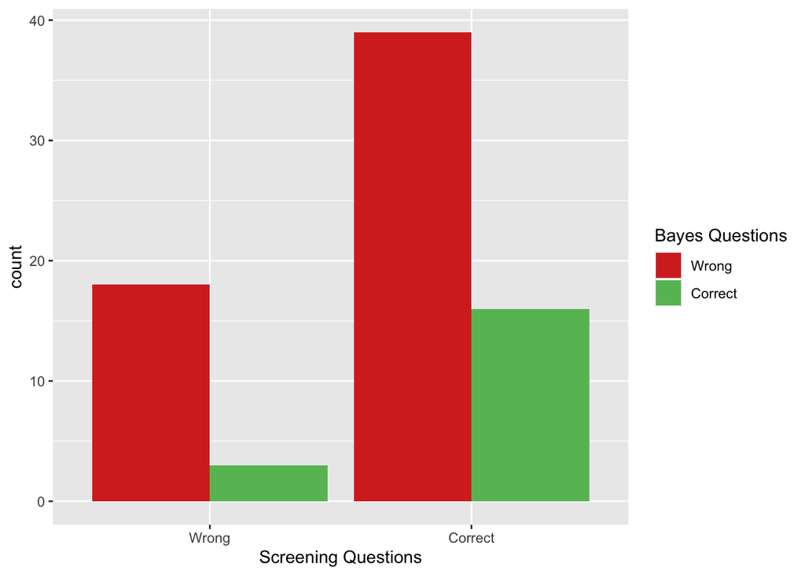

```r
pal = c(brewer.pal(11, "RdYlGn")[2], brewer.pal(11, "RdYlGn")[9])

dfCvd4Data %>%
  select(postId, stim, ans01, ans02, ans1, ans2) %>%
  mutate(corrFirstEgo = ifelse(ans01 == 'true positive', 1, 0),
         corrSecEgo = ifelse(ans02 == 'true positive', 1, 0),
         corrBayes = ifelse(ans1 == 57 & ans2 == 56, 1, 0)) %>%
  select(postId, stim, corrSecEgo, corrBayes) %>%
  ggplot(aes(x = factor(corrSecEgo), group = factor(corrBayes), fill = factor(corrBayes))) +
  geom_bar(position = "dodge") +
  scale_x_discrete("Screening Questions", labels = c("Wrong", "Correct")) +
  scale_fill_manual("Bayes Questions", labels = c("Wrong", "Correct"), values = pal)
```

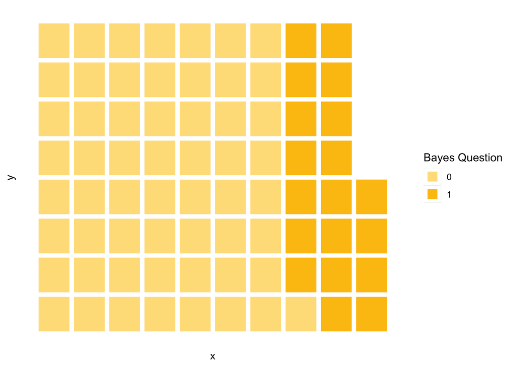

```r
library(ggwaffle)

ego0 <- dfCvd4Data %>%
  select(postId, stim, ans01, ans02, ans1, ans2) %>%
  mutate(corrFirstEgo = ifelse(ans01 == 'true positive', 1, 0),
         corrSecEgo = ifelse(ans02 == 'true positive', 1, 0),
         corrBayes = ifelse(ans1 == 57 & ans2 == 56, 1, 0)) %>%
  filter(corrSecEgo == 0) %>%
  select(postId, stim, corrSecEgo, corrBayes) %>%
  waffle_iron(aes_d(group = corrBayes)) %>%
  ggplot(aes(x, y, fill = as.factor(group))) +
  geom_waffle() +
  scale_fill_waffle("Bayes Question") +
  theme_waffle() +
  labs(title = "Got ego question wrong")

ego1 <- dfCvd4Data %>%
  select(postId, stim, ans01, ans02, ans1, ans2) %>%
  mutate(corrFirstEgo = ifelse(ans01 == 'true positive', 1, 0),
         corrSecEgo = ifelse(ans02 == 'true positive', 1, 0),
         corrBayes = ifelse(ans1 == 57 & ans2 == 56, 1, 0)) %>%
  filter(corrSecEgo == 1) %>%
  select(postId, stim, corrSecEgo, corrBayes) %>%
  waffle_iron(aes_d(group = corrBayes)) %>%
  ggplot(aes(x, y, fill = as.factor(group))) +
  geom_waffle() +
  scale_fill_waffle("Bayes Question") +
  theme_waffle() +
  labs(title = "Got ego question right")

dfCvd4Data %>%
  select(postId, stim, ans01, ans02, ans1, ans2) %>%
  mutate(corrFirstEgo = ifelse(ans01 == 'true positive', 1, 0),
         corrSecEgo = ifelse(ans02 == 'true positive', 1, 0),
         corrBayes = ifelse(ans1 == 57 & ans2 == 56, 1, 0)) %>%
  #filter(corrSecEgo == 0) %>%
  select(postId, stim, corrSecEgo, corrBayes) %>%
  waffle_iron(aes_d(group = corrBayes))%>%
  ggplot(aes(x, y, fill = as.factor(group))) +
  geom_waffle() +
  scale_fill_waffle("Bayes Question") +
  theme_waffle()
```

```r
library(gridExtra)
```

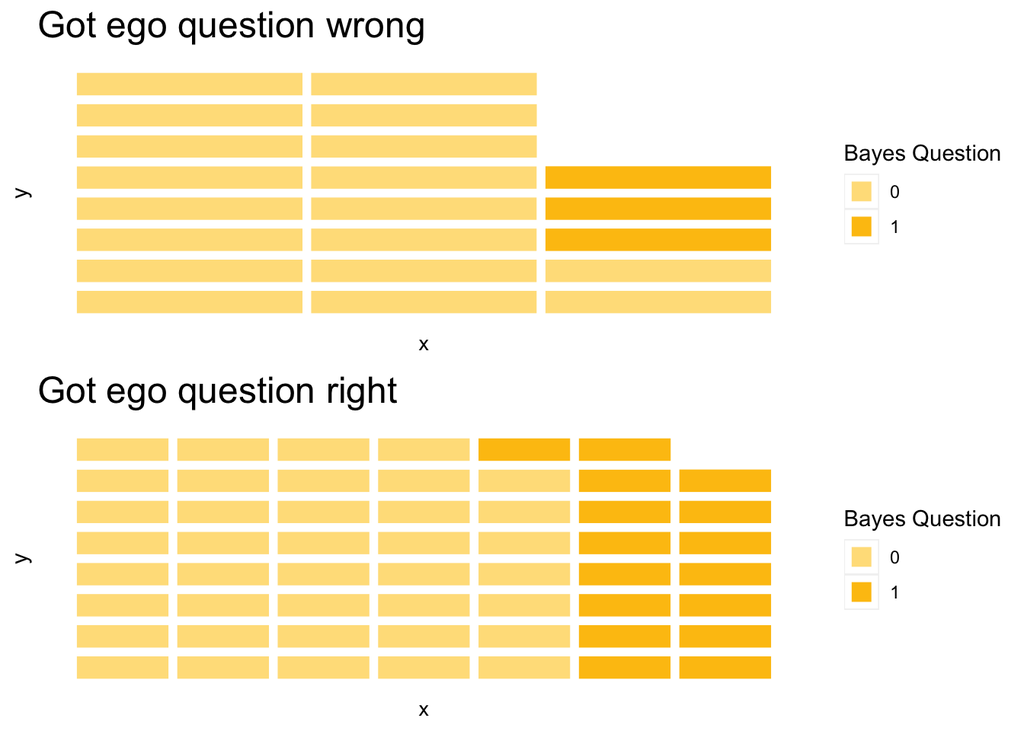

```r
grid.arrange(ego0, ego1)
```

```r
makeWaffle <- function(corrSecEgoNum){

funcData <- dfCvd4Data %>%
  select(postId, stim, ans01, ans02, ans1, ans2) %>%
  mutate(corrFirstEgo = ifelse(ans01 == 'true positive', 1, 0),
         corrSecEgo = ifelse(ans02 == 'true positive', 1, 0),
         corrBayes = ifelse(ans1 == 57 & ans2 == 56, 1, 0)) %>%
  filter(corrSecEgo == corrSecEgoNum)

math <- funcData %>%
  summarize(square = floor(sqrt(n())),
            leftOver = n() - square*square,
         extraCol = floor(leftOver/square),
         remainder = leftOver - extraCol*square,
         cols = square + extraCol,
         rows = square)

xFullCols <- math %>%
  select(cols) %>%
  first()
yFullRows <- math %>%
  select(rows) %>%
  first()
remainder <- math %>%
  select(remainder) %>%
  first()

x <- c(rep(1:xFullCols, each=yFullRows), rep(10, remainder))
y <- c(rep(1:yFullRows, xFullCols), 1:remainder)

funcData %>%
  select(postId, stim, corrSecEgo, corrBayes) %>%
  arrange(corrBayes) %>%
  cbind(x = x, y = y) %>%
  ggplot(aes(x, y, fill = as.factor(corrBayes))) +
  geom_waffle() +
  scale_fill_waffle() +
  theme_waffle()
}
```

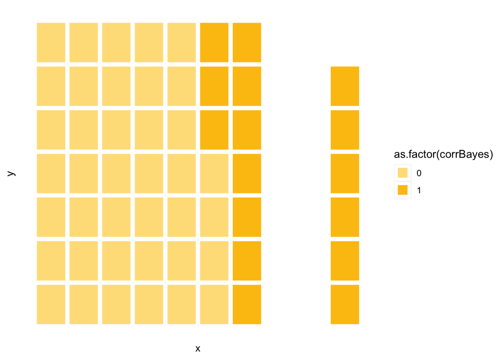

```r
makeWaffle(1)
```